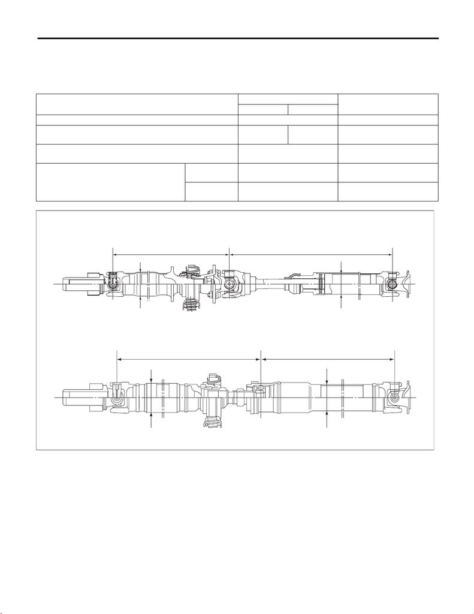

DS-2

General Description

DRIVE SHAFT SYSTEM

1. General Description

A: SPECIFICATION

1. PROPELLER SHAFT

Model

Except for STI model

STI model

CVT model MT model

Propeller shaft type EDJ 3UJ+CPS

Front propeller shaft joint-to-joint length: L

1

578.0 mm

(22.76 in)

735.5 mm

(28.96 in)

633.0 mm

(24.92 in)

Rear propeller shaft joint-to-joint length: L

2

723 mm

(28.46 in)

753.5 mm

(29.67 in)

Outer diameter of tube:

D

1

63.5 mm

(2.50 in)

70.0 mm

(2.76 in)

D

2

57.5 mm

(2.26 in)

57.0 mm

(2.24 in)

(A) 3UJ + CPS type (B) EDJ type

DS-00580

(B)

(A)

D1 D2

L1 L2

D1 D2

L1 L2

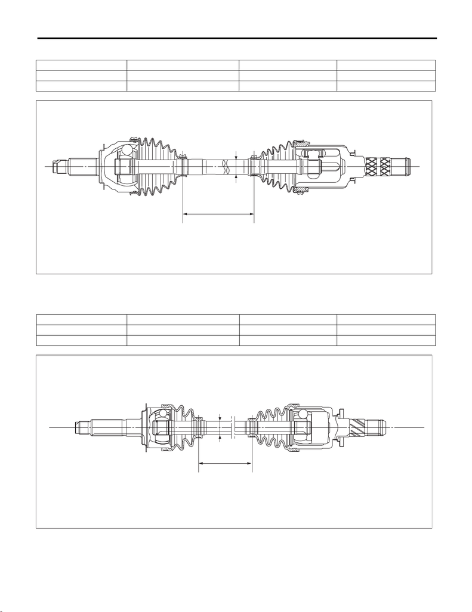

DS-3

General Description

DRIVE SHAFT SYSTEM

2. FRONT DRIVE SHAFT ASSEMBLY

3. REAR DRIVE SHAFT ASSEMBLY

Model Type of drive shaft Axle diameter φ mm (in) Axle length mm (in)

Except for STI model EBJ + PTJ 22 (0.87) 338.4 (13.32)

STI model AC + AAR 28 (1.10) 343.1 (13.51)

(A) Axle diameter (B) Axle length

Model Type of drive shaft Axle diameter φ mm (in) Axle length mm (in)

Except for STI model EBJ + DOJ 22 (0.87) 388.5 (15.3)

STI model EBJ + EDJ 25 (0.98) 339.5 (13.37)

(A) Axle diameter (B) Axle length

DS-00478

(B)

(A)

DS-00409

(B)

(A)

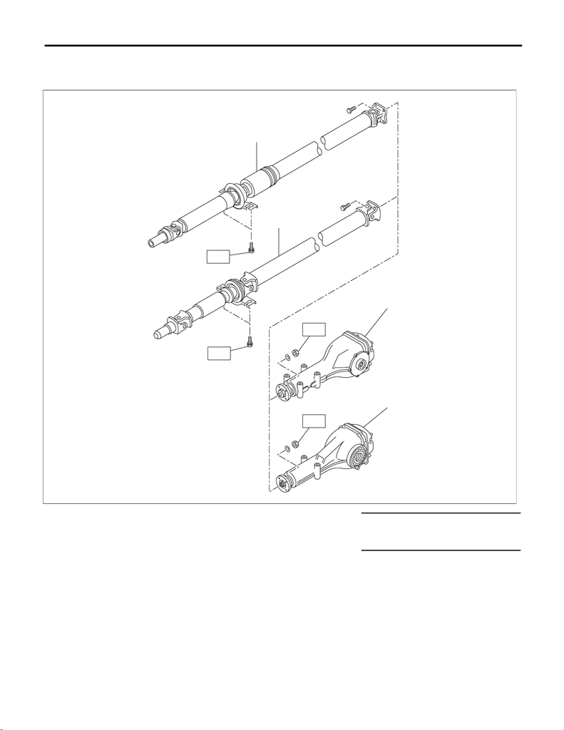

DS-4

General Description

DRIVE SHAFT SYSTEM

B: COMPONENT

1. PROPELLER SHAFT

(1) Propeller shaft (3UJ-type) (3) Rear differential (T-type) Tightening torque: N·m (kgf-m, ft-lb)

(2) Propeller shaft (EDJ-type) (4) Rear differential (VA2-type) T1: 31 (3.2, 22.9)

T2: 52 (5.3, 38.4)

T1

(3)

T2

(1)

DS-00511

(4)

T1

(2)

T2

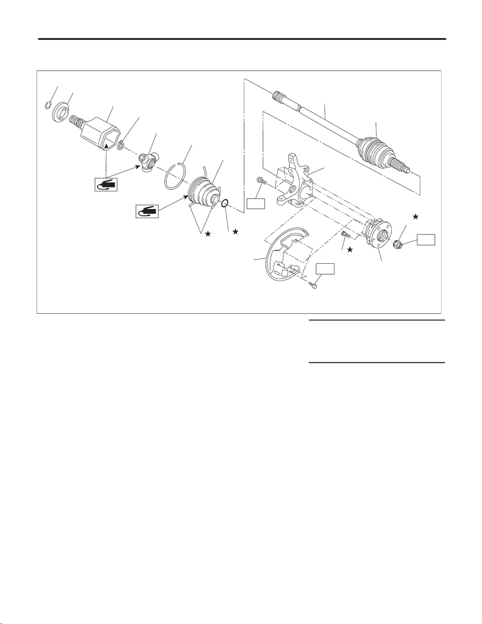

DS-5

General Description

DRIVE SHAFT SYSTEM

2. FRONT AXLE

• Except for STI model

(1) Circlip (9) O-ring Tightening torque: N·m (kgf-m, ft-lb)

(2) Baffle plate (10) EBJ shaft ASSY T1: 18 (1.8, 13.3)

(3) Outer race (PTJ) (11) Boot (AC) T2: 65 (6.6, 47.9)

(4) Snap ring (12) Housing T3: 220 (22.4, 162.3)

(5) Trunnion (13) Back plate - front brake

(6) Snap ring (14) Hub bolt

(7) Boot band (15) Hub unit COMPL - front axle

(8) Boot (PTJ) (16) Axle nut

(15)

(16)

(11)

(10)

(14)

(12)

T2

T3

DS-00576

(13)

(3)

(2)

(1)

(4)

(5)

(7)

(8)

(9)

(6)

T1

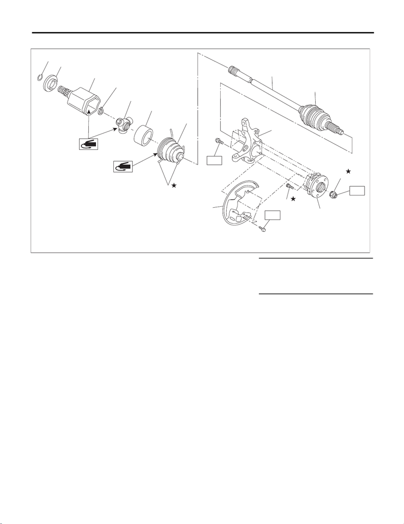

DS-6

General Description

DRIVE SHAFT SYSTEM

• STI model

(1) Circlip (9) AC shaft ASSY Tightening torque: N·m (kgf-m, ft-lb)

(2) Baffle plate (10) Boot (AC) T1: 18 (1.8, 13.3)

(3) Outer race (AAR) (11) Housing T2: 65 (6.6, 47.9)

(4) Snap ring (12) Back plate - front brake T3: 220 (22.4, 162.3)

(5) Trunnion (13) Hub bolt

(6) Grommet (14) Hub unit COMPL - front axle

(7) Boot band (15) Axle nut

(8) Boot (AAR)

DS-00579

(14)

(15)

(10)

(9)

(13)

(11)

T1

T2

T3

(12)

(3)

(2)

(1)

(4)

(5)

(6)

(7)

(8)

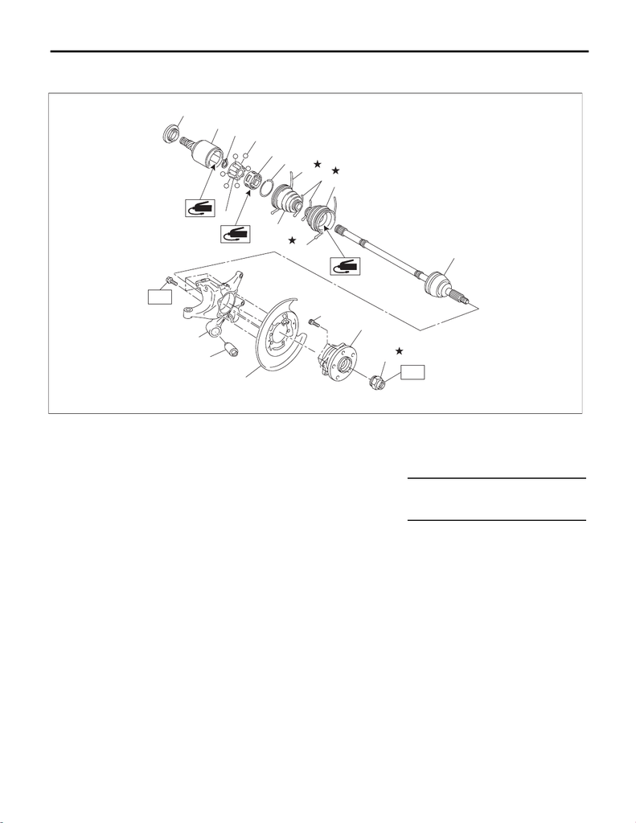

DS-7

General Description

DRIVE SHAFT SYSTEM

3. REAR AXLE

• Except for STI model

(1) Baffle plate (8) Boot band (15) Hub bolt

(2) Outer race (DOJ) (9) Boot (DOJ) (16) Hub unit COMPL - rear axle

(3) Snap ring (10) Boot (BJ) (17) Axle nut

(4) Inner race (11) EBJ shaft ASSY

(5) Ball (12) Rear axle housing Tightening torque: N·m (kgf-m, ft-lb)

(6) Cage (13) Bushing T1: 65 (6.6, 47.9)

(7) Snap ring (14) Back plate - rear brake T2: 190 (19.4, 140.1)

T2

T1

DS-00577

(15)

(16)

(5)

(4)

(6)

(3)

(2)

(1)

(11)

(10)

(9)

(8)

(8)

(8)

(7)

(14)

(17)

(12)

(13)

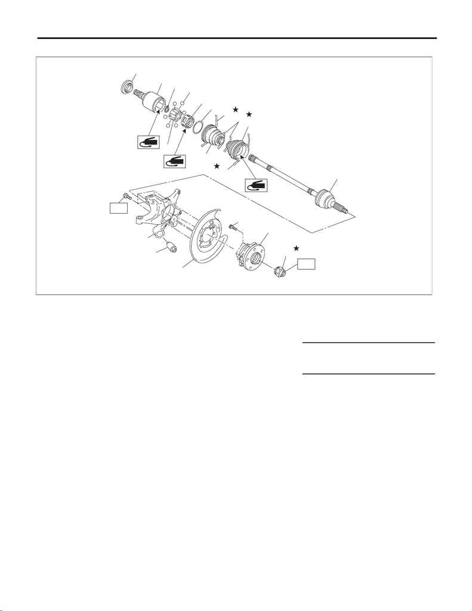

DS-8

General Description

DRIVE SHAFT SYSTEM

• STI model

C: CAUTION

• When performing any work, always wear work clothes, a work cap and protective shoes. Additionally, wear

a helmet, protective goggles, etc. if necessary.

• Remove contamination including dirt and corrosion before removal, installation, disassembly or assembly.

• When performing a repair, identify the cause of trouble and avoid unnecessary removal, disassembly and

replacement.

• Some vehicle components are extremely hot immediately after driving. Be wary of receiving burns from

heated parts.

• Use SUBARU genuine grease, the recommended or equivalent. Do not mix grease etc. of different grades

or manufacturers.

• Be sure to tighten fasteners including bolts and nuts to the specified torque.

• Always use the jack-up point when the shop jacks or rigid racks are used to support the vehicle.

• Apply grease onto sliding or revolving surfaces before installation.

• Be sure that the surface of brake disc, brake pad or brake shoe is free from grease or oil.

• Do not secure a part in a vise directly. Place cushioning materials such as wood blocks, aluminum plates,

or waste cloth between the part and the vise.

• When the suspension-related components have been removed or replaced, perform “VDC sensor mid-

point setting mode” of the VDC. <Ref. to VDC-16, ADJUSTMENT, VDC Control Module and Hydraulic Con-

trol Unit (VDCCM&H/U).>

(1) Baffle plate (8) Boot band (15) Hub bolt

(2) Outer race (EDJ) (9) Boot (EDJ) (16) Hub unit COMPL - rear axle

(3) Snap ring (10) Boot (EBJ) (17) Axle nut

(4) Inner race (11) EBJ shaft ASSY

(5) Ball (12) Rear axle housing Tightening torque: N·m (kgf-m, ft-lb)

(6) Cage (13) Bushing T1: 65 (6.6, 47.9)

(7) Snap ring (14) Back plate - rear brake T2: 190 (19.4, 140.1)

T2

T1

DS-00577

(15)

(16)

(5)

(4)

(6)

(3)

(2)

(1)

(11)

(10)

(9)

(8)

(8)

(8)

(7)

(14)

(17)

(12)

(13)

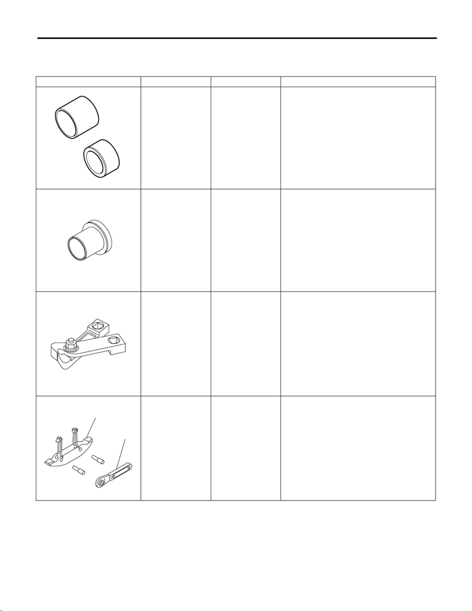

DS-9

General Description

DRIVE SHAFT SYSTEM

D: PREPARATION TOOL

1. SPECIAL TOOL

ILLUSTRATION Part No. DESCRIPTION REMARKS

20099PA010 INSTALLER &

REMOVER

• Used for replacing the bushing - trailing link of

the housing assembly - rear axle.

• Used together with BUSHING REMOVER

(20099FG000).

20099FG000 BUSHING

REMOVER

• Used for replacing the bushing - trailing link of

the housing assembly - rear axle.

• Used together with base part of INSTALLER &

REMOVER (20099PA010).

28099AC000 BOOT BAND PLIER Used for tightening the band - boot.

(for front drive shaft)

925091000 BAND TIGHTENING

TOOL

Used for tightening the band - boot.

(A) Jig for the band

(B) Ratchet wrench

ST20099PA010

ST20099FG000

ST28099AC000

ST-925091000

(A)

(B)

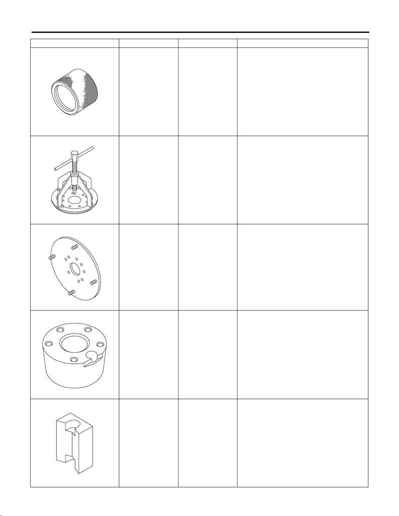

DS-10

General Description

DRIVE SHAFT SYSTEM

18675AA000 DIFFERENTIAL

SIDE OIL SEAL

INSTALLER

Used for installing the differential side retainer oil

seal.

926470000 AXLE SHAFT

PULLER

• Used for removing the drive shaft.

• Used together with AXLE SHAFT PULLER

PLATE (28099PA110).

28099PA110 AXLE SHAFT

PULLER PLATE

• Used for removing the drive shaft.

• Exchange with the plate of the AXLE SHAFT

PULLER (926470000) to use.

28099PA080 HUB STAND Used for assembling the bolt - hub of the hub.

28399AG000 HUB STAND Used for extracting the bolt - hub.

ILLUSTRATION Part No. DESCRIPTION REMARKS

ST18675AA000

ST-926470000

ST28099PA110

ST28099PA080

ST28399AG000

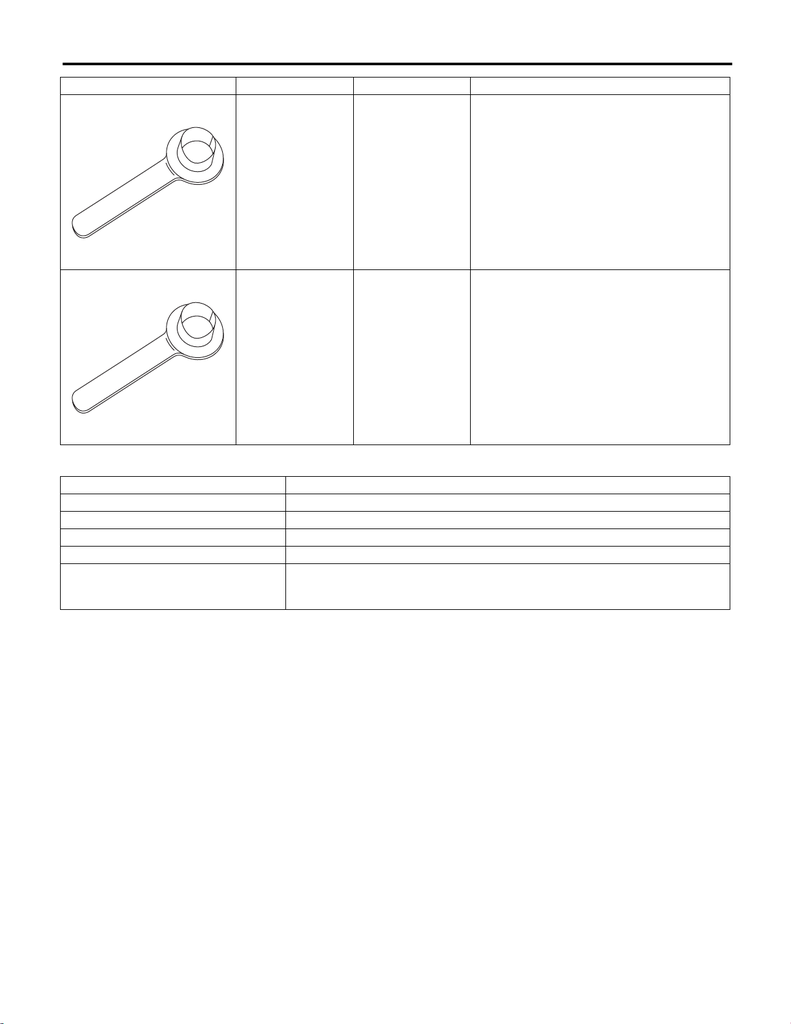

DS-11

General Description

DRIVE SHAFT SYSTEM

2. GENERAL TOOL

28399SA010 OIL SEAL PROTEC-

TOR

• Used for installing front drive shaft into front

differential.

• For protecting the oil seal.

28099PA090 OIL SEAL PROTEC-

TOR

• Used for installing the rear drive shaft to the

rear differential.

• For protecting the oil seal.

TOOL NAME REMARKS

Tie-rod ball joint puller Used for disconnecting joints.

Dial gauge Used for inspecting the propeller shaft run-out.

Extension cap Used for preventing leakage of gear oil or ATF.

Crowbar Used for extracting drive shaft.

Needle nose pliers Used for tightening the band - boot of the rear drive shaft.

• Snap-on 96BCP

Or equivalent.

ILLUSTRATION Part No. DESCRIPTION REMARKS

ST28399SA010

ST28099PA090